# Practical Machine Learning Assignment

Vasileios Vasileiou

Sunday, June 21, 2015

Using devices such as Jawbone Up, Nike FuelBand, and Fitbit it is now possible to collect a large amount of data about personal activity relatively inexpensively. These type of devices are part of the quantified self movement – a group of enthusiasts who take measurements about themselves regularly to improve their health, to find patterns in their behavior, or because they are tech geeks. One thing that people regularly do is quantify how much of a particular activity they do, but they rarely quantify how well they do it. In this project, our goal is to use data from accelerometers on the belt, forearm, arm, and dumbell of 6 participants. They were asked to perform barbell lifts correctly and incorrectly in 5 different ways. More information is available from the website here: http://groupware.les.inf.puc-rio.br/har (see the section on the Weight Lifting Exercise Dataset).

First we Read the Data and we examine a barplot of the 5 different ways of barbell lifts

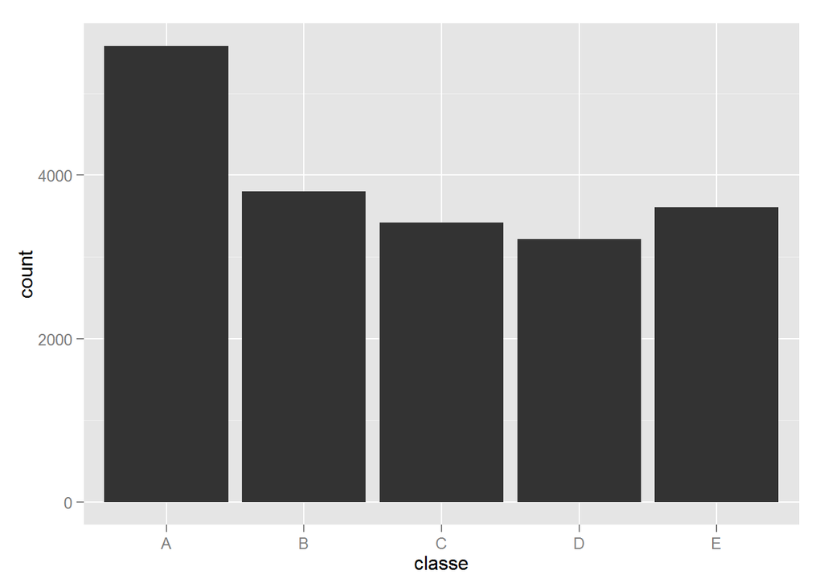

```r
set.seed(8044193)

library("ggplot2")
library("caret")
train <- read.csv("pml-training.csv", na.strings = c("", NA, "#DIV/0!"))
test <- read.csv("pml-testing.csv", na.strings = c("", NA, "#DIV/0!"))

qplot(classe, data = train)
```

Then we get rid of the variables with more than 80% of missing values

```r
mis <- sapply(train,is.na)
mis <- apply(mis,2,sum)
mis.prop <- mis/dim(train)[1]
train <- train[-which(mis.prop > 0.8)]
test <- test[-which(mis.prop > 0.8)]
```

After we get rid of the factor variables as they don’t seem very useful in this project, we standardize and we impute the missing data using k-nearest neighbours

```r
nums  <- sapply(train, is.numeric)
nums[1]  <- FALSE
dummy <- train[ , nums]

## Standardizing
preObj <- preProcess(dummy, method = c("center","scale"))
dummy <- predict(preObj, dummy)

## Imputing missing data
mis <- preProcess(dummy,method = "knnImpute")
dummy <- predict(mis, dummy)
train <- data.frame(dummy, train$classe)
```

Then We fit two models using 15-fold Cross Validation

```r
## 15-fold Cross Validation
fitControl <- trainControl(method = "cv", number = 15)
## Model1 Naive Bayes
nbFit <- train(train.classe ~ ., data = train, method = "nb", trControl = fitControl)
## Model 2 Random Forest
rfFit <- train(train.classe ~ ., data = train, method = "rf", trControl = fitControl)
```

Excellent accuracy for the random forest model with high accuracy (over 99%) and 0.06% in sample error. On the other hand, the Naive Bayes Model did not perform as good as we can see from the tables. Of course, one would expect that the out of sample error would be higher because the models are tuned to fit the training data

```r
rfFit
```

```
## Random Forest
##
## 19622 samples
##    55 predictor
##     5 classes: 'A', 'B', 'C', 'D', 'E'
##
## No pre-processing
## Resampling: Cross-Validated (15 fold)
##
## Summary of sample sizes: 18314, 18314, 18313, 18315, 18313, 18315, ...
##
## Resampling results across tuning parameters:
##
##   mtry  Accuracy   Kappa      Accuracy SD   Kappa SD
##    2    0.9981142  0.9976146  0.0014698980  0.001859449
##   28    0.9994394  0.9992909  0.0005381242  0.000680691
##   55    0.9991336  0.9989041  0.0008603817  0.001088350
##
## Accuracy was used to select the optimal model using  the largest value.
## The final value used for the model was mtry = 28.
```

```r
print(nbFit)
```

```
## Naive Bayes
##
## 19622 samples
##    55 predictor
##     5 classes: 'A', 'B', 'C', 'D', 'E'
##
## No pre-processing
## Resampling: Cross-Validated (15 fold)
##
## Summary of sample sizes: 18314, 18315, 18314, 18315, 18313, 18314, ...
##
## Resampling results across tuning parameters:
##
##   usekernel  Accuracy   Kappa      Accuracy SD  Kappa SD
##   FALSE      0.5004617  0.3833449  0.01685602   0.01865455
##    TRUE      0.7630198  0.6973576  0.01112963   0.01438049
##
## Tuning parameter 'fL' was held constant at a value of 0
## Accuracy was used to select the optimal model using  the largest value.
## The final values used for the model were fL = 0 and usekernel = TRUE.
```

```r
rfFit$finalModel
```

```
##
## Call:
##  randomForest(x = x, y = y, mtry = param$mtry)
##                Type of random forest: classification
##                      Number of trees: 500
## No. of variables tried at each split: 28
##
##         OOB estimate of  error rate: 0.04%
## Confusion matrix:
##      A    B    C    D    E  class.error
## A 5580    0    0    0    0 0.0000000000
## B    1 3796    0    0    0 0.0002633658
## C    0    4 3418    0    0 0.0011689071
## D    0    0    2 3213    1 0.0009328358
## E    0    0    0    0 3607 0.0000000000
```

Then we standardize the testing set based on the standardization of the training set

```r
test <- test[,-c(1,2,5,6,60)]
test <- predict(preObj, test)
```

And then we Compare the Predictions

```r
R.Forest <- predict(rfFit, newdata = test)
N.Bayes <- predict(nbFit, newdata = test)
print(table(R.Forest,N.Bayes))
```

```
##         N.Bayes
## R.Forest A B C D E
##        A 7 0 0 0 0
##        B 4 3 1 0 0
##        C 1 0 0 0 0
##        D 0 0 0 1 0
##        E 1 0 0 0 2
```

```r
13/20
```

```
## [1] 0.65
```